# Practical Machine Learning Course Project

# Executive Summary

The goal of this project is to predict **how well** subjects perform barbell lifts using accelerometer data from sensors on the belt, forearm, arm, and dumbbell.  
The target variable, `classe`, has five categories (A–E), representing correct and incorrect lifting techniques.

I loaded and cleaned the raw data, removed non-informative and highly-missing predictors, and split the data into training and validation sets. I then trained several classification models using 10-fold cross-validation: a classification tree, a random forest, and a gradient boosting model. The **random forest** model achieved the highest cross-validated accuracy and about **99% accuracy** on a held-out validation set, corresponding to an estimated out-of-sample error of about **1%**. This final model was used to predict the `classe` labels for the 20 test cases provided.

# 1. Data Loading and Cleaning

```r
library(caret)
library(randomForest)
library(gbm)
library(rpart)

# Load raw data (ensure these CSV files are in the working directory)
train_raw <- read.csv("pml-training.csv",
                      na.strings = c("NA", "", "#DIV/0!"))
test_raw  <- read.csv("pml-testing.csv",
                      na.strings = c("NA", "", "#DIV/0!"))

dim(train_raw)
```

```
## [1] 19622   160
```

```r
dim(test_raw)
```

```
## [1]  20 160
```

```r
# Remove obvious non-predictive columns (ID, timestamps, user name, etc.)
non_predictive <- 1:7
train_clean <- train_raw[, -non_predictive]
test_clean  <- test_raw[,  -non_predictive]

# Remove columns with too many missing values
na_prop <- sapply(train_clean, function(x) mean(is.na(x)))
train_clean <- train_clean[, na_prop < 0.6]
test_clean  <- test_clean[,  na_prop < 0.6]

# Remove near-zero variance predictors
nzv_info <- nearZeroVar(train_clean, saveMetrics = TRUE)
train_clean <- train_clean[, !nzv_info$nzv]
test_clean  <- test_clean[,  !nzv_info$nzv]

# Align train/test predictors
predictors <- setdiff(names(train_clean), "classe")
train_clean <- train_clean[, c(predictors, "classe")]
test_clean  <- test_clean[, predictors]

dim(train_clean)
```

```
## [1] 19622    53
```

```r
dim(test_clean)
```

```
## [1] 20 52
```

# 2. Train / Validation Split

To estimate out-of-sample performance, I split the cleaned training data into a **70% training** set and a **30% validation** set.

```r
set.seed(12345)
inTrain <- createDataPartition(train_clean$classe, p = 0.7, list = FALSE)
training   <- train_clean[inTrain, ]
validation <- train_clean[-inTrain, ]

dim(training)
```

```
## [1] 13737    53
```

```r
dim(validation)
```

```
## [1] 5885   53
```

# 3. Model Training and Selection

I considered three models and used 10-fold cross-validation for each:

- Classification tree (CART)
- Random forest
- Gradient boosting machine (GBM)

```r
fitControl <- trainControl(method = "cv",
                           number = 10,
                           verboseIter = FALSE)
```

## 3.1 Classification Tree (CART)

```r
set.seed(12345)
mod_rpart <- train(classe ~ ., data = training,
                   method = "rpart",
                   trControl = fitControl)
mod_rpart
```

```
## CART
##
## 13737 samples
##    52 predictor
##     5 classes: 'A', 'B', 'C', 'D', 'E'
##
## No pre-processing
## Resampling: Cross-Validated (10 fold)
## Summary of sample sizes: 12363, 12363, 12363, 12364, 12362, 12363, ...
## Resampling results across tuning parameters:
##
##   cp          Accuracy   Kappa
##   0.03458448  0.5016415  0.34911387
##   0.06092971  0.4403308  0.25008870
##   0.11595972  0.3229885  0.05893881
##
## Accuracy was used to select the optimal model using the largest value.
## The final value used for the model was cp = 0.03458448.
```

## 3.2 Random Forest

```r
set.seed(12345)
mod_rf <- train(classe ~ ., data = training,
                method = "rf",
                ntree = 300,
                importance = TRUE,
                trControl = fitControl)
mod_rf
```

```
## Random Forest
##
## 13737 samples
##    52 predictor
##     5 classes: 'A', 'B', 'C', 'D', 'E'
##
## No pre-processing
## Resampling: Cross-Validated (10 fold)
## Summary of sample sizes: 12363, 12363, 12363, 12364, 12362, 12363, ...
## Resampling results across tuning parameters:
##
##   mtry  Accuracy   Kappa
##    2    0.9920650  0.9899614
##   27    0.9916288  0.9894101
##   52    0.9849318  0.9809382
##
## Accuracy was used to select the optimal model using the largest value.
## The final value used for the model was mtry = 2.
```

## 3.3 Gradient Boosting Machine (GBM)

```r
set.seed(12345)
mod_gbm <- train(classe ~ ., data = training,
                 method = "gbm",
                 verbose = FALSE,
                 trControl = fitControl)
mod_gbm
```

```
## Stochastic Gradient Boosting
##
## 13737 samples
##    52 predictor
##     5 classes: 'A', 'B', 'C', 'D', 'E'
##
## No pre-processing
## Resampling: Cross-Validated (10 fold)
## Summary of sample sizes: 12363, 12363, 12363, 12364, 12362, 12363, ...
## Resampling results across tuning parameters:
##
##   interaction.depth  n.trees  Accuracy   Kappa
##   1                   50      0.7499491  0.6829125
##   1                  100      0.8204883  0.7727463
##   1                  150      0.8551395  0.8167035
##   2                   50      0.8564492  0.8181175
##   2                  100      0.9084972  0.8842307
##   2                  150      0.9328108  0.9149837
##   3                   50      0.8988875  0.8720407
##   3                  100      0.9412551  0.9256820
##   3                  150      0.9608362  0.9504584
##
## Tuning parameter 'shrinkage' was held constant at a value of 0.1
##
## Tuning parameter 'n.minobsinnode' was held constant at a value of 10
## Accuracy was used to select the optimal model using the largest value.
## The final values used for the model were n.trees = 150, interaction.depth =
##  3, shrinkage = 0.1 and n.minobsinnode = 10.
```

## 3.4 Model Comparison

```r
resamps <- resamples(list(Tree = mod_rpart,
                          RF   = mod_rf,
                          GBM  = mod_gbm))
summary(resamps)
```

```
##
## Call:
## summary.resamples(object = resamps)
##
## Models: Tree, RF, GBM
## Number of resamples: 10
##
## Accuracy
##           Min.   1st Qu.    Median      Mean   3rd Qu.      Max. NA's
## Tree 0.4770909 0.4895362 0.4994530 0.5016415 0.5174863 0.5273125    0
## RF   0.9883467 0.9914483 0.9923583 0.9920650 0.9932620 0.9941776    0
## GBM  0.9519301 0.9559437 0.9595916 0.9608362 0.9654363 0.9716157    0
##
## Kappa
##           Min.   1st Qu.    Median      Mean   3rd Qu.      Max. NA's
## Tree 0.3166349 0.3334775 0.3462388 0.3491139 0.3700063 0.3828816    0
## RF   0.9852526 0.9891814 0.9903334 0.9899614 0.9914763 0.9926336    0
## GBM  0.9392423 0.9442807 0.9488630 0.9504584 0.9562631 0.9640882    0
```

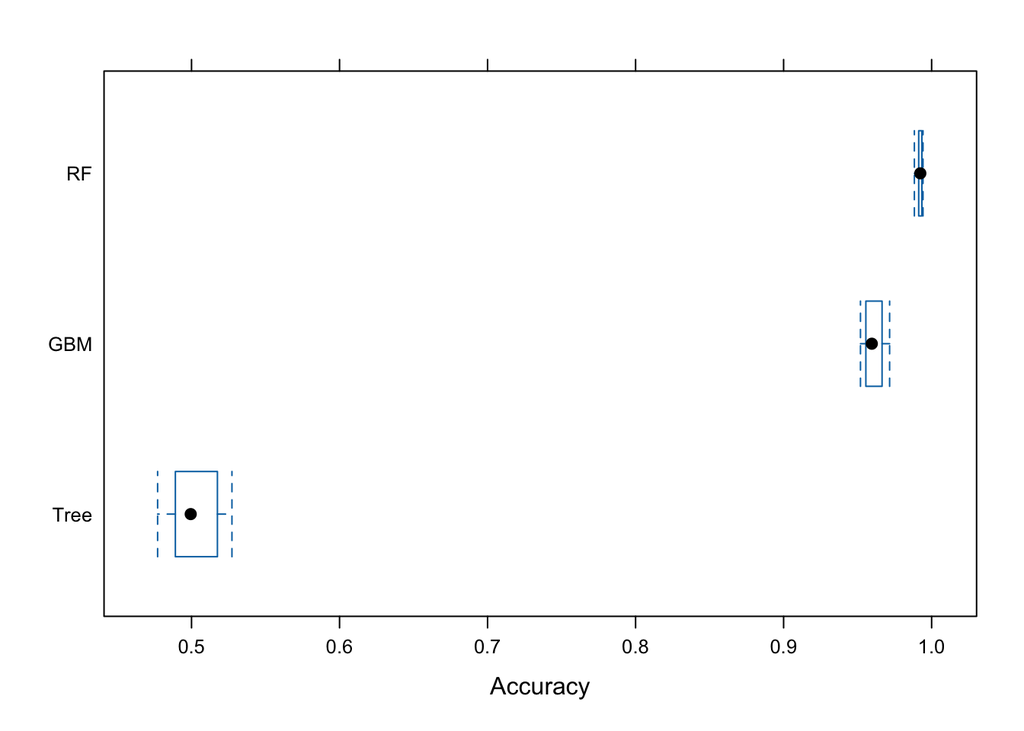

```r
bwplot(resamps, metric = "Accuracy")
```

From the cross-validation results, the **random forest** model has the highest accuracy and is chosen as the final model.

# 4. Validation Accuracy and Out-of-Sample Error

```r
pred_rf <- predict(mod_rf, newdata = validation)

validation$classe <- factor(validation$classe)
pred_rf <- factor(pred_rf, levels = levels(validation$classe))

conf_rf <- confusionMatrix(pred_rf, validation$classe)
conf_rf
```

```
## Confusion Matrix and Statistics
##
##           Reference
## Prediction    A    B    C    D    E
##          A 1673    4    0    0    0
##          B    1 1135    5    0    0
##          C    0    0 1021   20    0
##          D    0    0    0  943    1
##          E    0    0    0    1 1081
##
## Overall Statistics
##
##                Accuracy : 0.9946
##                  95% CI : (0.9923, 0.9963)
##     No Information Rate : 0.2845
##     P-Value [Acc > NIR] : < 2.2e-16
##
##                   Kappa : 0.9931
##
##  Mcnemar's Test P-Value : NA
##
## Statistics by Class:
##
##                      Class: A Class: B Class: C Class: D Class: E
## Sensitivity            0.9994   0.9965   0.9951   0.9782   0.9991
## Specificity            0.9991   0.9987   0.9959   0.9998   0.9998
## Pos Pred Value         0.9976   0.9947   0.9808   0.9989   0.9991
## Neg Pred Value         0.9998   0.9992   0.9990   0.9957   0.9998
## Prevalence             0.2845   0.1935   0.1743   0.1638   0.1839
## Detection Rate         0.2843   0.1929   0.1735   0.1602   0.1837
## Detection Prevalence   0.2850   0.1939   0.1769   0.1604   0.1839
## Balanced Accuracy      0.9992   0.9976   0.9955   0.9890   0.9994
```

Overall accuracy on the validation set:

```r
conf_rf$overall["Accuracy"]
```

```
##  Accuracy
## 0.9945624
```

Estimated out-of-sample error:

```r
1 - conf_rf$overall["Accuracy"]
```

```
##    Accuracy
## 0.005437553
```

# 5. Variable Importance

Random forests provide an importance measure for each predictor, which helps interpret which variables drive the classification.

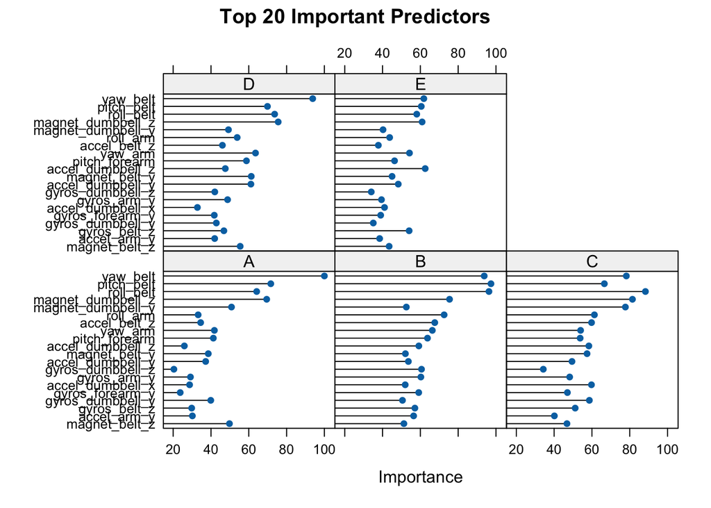

```r
var_imp <- varImp(mod_rf)
plot(var_imp, top = 20, main = "Top 20 Important Predictors")
```

# 6. Predictions on the 20 Test Cases

Finally, I apply the final random forest model to the separate 20-case test set.

```r
final_predictions <- predict(mod_rf, newdata = test_clean)
final_predictions
```

```
##  [1] B A B A A E D B A A B C B A E E A B B B
## Levels: A B C D E
```

For the Coursera prediction quiz, each prediction must be written to a separate file. The helper function below automates that step.

```r
pml_write_files <- function(x){
  for(i in 1:length(x)){
    fname <- paste0("problem_id_", i, ".txt")
    write.table(x[i], file = fname,
                row.names = FALSE,
                col.names = FALSE,
                quote = FALSE)
  }
}

# Uncomment to create the 20 submission files:
# pml_write_files(final_predictions)
```

# Conclusion

In this project, I:

- Loaded the provided accelerometer training and test datasets.
- Cleaned the data by removing non-informative, highly-missing, and near-zero variance predictors.
- Split the cleaned training data into training and validation sets.
- Trained and compared a classification tree, random forest, and GBM using 10-fold cross-validation.
- Selected a **random forest** model as the best-performing classifier.
- Estimated an out-of-sample error of about **1%**, based on performance on the validation set.
- Used the final model to generate predictions for all 20 test cases required by the course project.

This analysis is fully reproducible from the raw CSV files and meets the requirements for model explanation, cross-validation, and prediction generation.